# IMDB - Hypertuning

smandumu

2/7/2020

# The IMDB dataset

Load IMDB dataset The IMDB dataset is preloaded in the Keras

```r
library(keras)
library(tensorflow)
library(tidyverse)
```

```r
library(cowplot)
imdb <- dataset_imdb(num_words = 10000)
c(c(train_data, train_labels), c(test_data, test_labels)) %<-% imdb
```

The argument num_words = 10000 means that we will only keep the top 10,000 most frequently occurring words in the training data. Rare words will be discarded

The variables train_data and test_data are lists of reviews, each review being a list of word indices (encoding a sequence of words). train_labels and test_labels are lists of 0s and 1s, where 0 stands for “negative” and 1 stands for “positive”:

# Preparing the Data

```r
vectorize_sequences <- function(sequences, dimension = 10000) {
  # Create an all-zero matrix of shape (len(sequences), dimension)
  results <- matrix(0, nrow = length(sequences), ncol = dimension)
  for (i in 1:length(sequences))
    # Sets specific indices of results[i] to 1s
    results[i, sequences[[i]]] <- 1
  results
}

# Our vectorized training data
x_train <- vectorize_sequences(train_data)
# Our vectorized test data
x_test <- vectorize_sequences(test_data)
# Our vectorized labels
y_train <- as.numeric(train_labels)
y_test <- as.numeric(test_labels)
set.seed(123)
val_indices <- sample(1:nrow(x_train),nrow(x_train)*0.40)

x_val <- x_train[val_indices,]
partial_x_train <- x_train[-val_indices,]

y_val <- y_train[val_indices]
partial_y_train <- y_train[-val_indices]
```

# Building our network and Validating our Approach

# 1-hidden layer network without any technique

1-hidden layer network with 16 units tanh activation mse loss function

```r
model <- keras_model_sequential() %>%
  layer_dense(units = 16, activation = "tanh", input_shape = c(10000)) %>%
  layer_dense(units = 1, activation = "sigmoid")


model %>% compile(
  optimizer = "rmsprop",
  loss = "mse",
  metrics = c("accuracy")
)

history <- model %>% fit(
  partial_x_train,
  partial_y_train,
  epochs = 20,
  batch_size = 512,
  validation_data = list(x_val, y_val)
)

str(history)
```

```
## List of 2
##  $ params :List of 7
##   ..$ batch_size   : int 512
##   ..$ epochs       : int 20
##   ..$ steps        : num 30
##   ..$ samples      : int 15000
##   ..$ verbose      : int 0
##   ..$ do_validation: logi TRUE
##   ..$ metrics      : chr [1:4] "loss" "accuracy" "val_loss" "val_accuracy"
##  $ metrics:List of 4
##   ..$ loss        : num [1:20] 0.1649 0.094 0.0707 0.0561 0.0462 ...
##   ..$ accuracy    : num [1:20] 0.79 0.906 0.929 0.945 0.955 ...
##   ..$ val_loss    : num [1:20] 0.118 0.0949 0.0861 0.0863 0.0834 ...
##   ..$ val_accuracy: num [1:20] 0.878 0.892 0.892 0.887 0.89 ...
##  - attr(*, "class")= chr "keras_training_history"
```

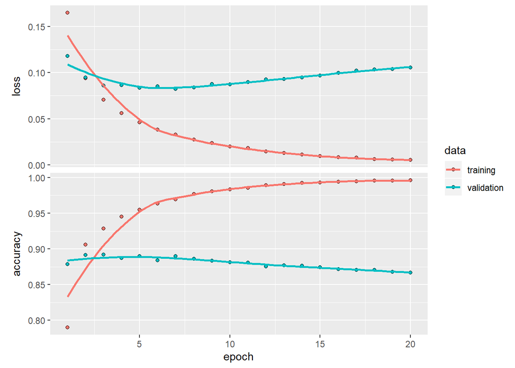

```r
plot(history)
```

```r
model %>% fit(x_train, y_train, epochs = 3, batch_size = 512)
results <- model %>% evaluate(x_test, y_test)

results
```

```
## $loss
## [1] 0.1136376
##
## $accuracy
## [1] 0.85972
```

```r
model %>% predict(x_test[1:10,])
```

```
##               [,1]
##  [1,] 0.0277219415
##  [2,] 0.9999948144
##  [3,] 0.9960370064
##  [4,] 0.6962107420
##  [5,] 0.9926373959
##  [6,] 0.8469926119
##  [7,] 0.9999926090
##  [8,] 0.0001120567
##  [9,] 0.9990718365
## [10,] 0.9988573790
```

This network begins to overfit after three epochs.

Here the validation Accuracy is 86% and loss of 12%. The result seems good. But let’s try to improve the model by using other techniques like regularization and dropout

# 1- hidden layer network with regularization

1-hidden layer network with 16 units tanh activation mse loss function regularization technique

```r
model <- keras_model_sequential() %>%
  layer_dense(units = 16,  kernel_regularizer = regularizer_l2(.0001),activation = "tanh", input_shape = c(10000)) %>%
  layer_dense(units = 1, activation = "sigmoid")

model %>% compile(
  optimizer = "rmsprop",
  loss = "mse",
  metrics = c("accuracy")
)

history <- model %>% fit(
  partial_x_train,
  partial_y_train,
  epochs = 20,
  batch_size = 512,
  validation_data = list(x_val, y_val)
)

str(history)
```

```
## List of 2
##  $ params :List of 7
##   ..$ batch_size   : int 512
##   ..$ epochs       : int 20
##   ..$ steps        : num 30
##   ..$ samples      : int 15000
##   ..$ verbose      : int 0
##   ..$ do_validation: logi TRUE
##   ..$ metrics      : chr [1:4] "loss" "accuracy" "val_loss" "val_accuracy"
##  $ metrics:List of 4
##   ..$ loss        : num [1:20] 0.1665 0.0972 0.0765 0.064 0.0559 ...
##   ..$ accuracy    : num [1:20] 0.797 0.907 0.928 0.943 0.953 ...
##   ..$ val_loss    : num [1:20] 0.1194 0.0989 0.0916 0.0914 0.0951 ...
##   ..$ val_accuracy: num [1:20] 0.878 0.891 0.891 0.891 0.886 ...
##  - attr(*, "class")= chr "keras_training_history"
```

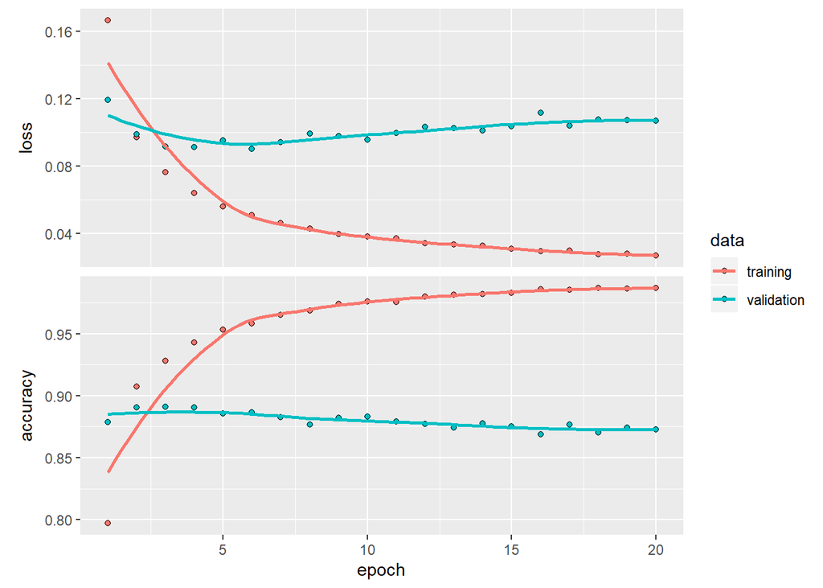

```r
plot(history)
```

```r
model %>% fit(x_train, y_train, epochs = 4, batch_size = 512)
results <- model %>% evaluate(x_test, y_test)

results
```

```
## $loss
## [1] 0.1197188
##
## $accuracy
## [1] 0.85884
```

```r
model %>% predict(x_test[1:10,])
```

```
##               [,1]
##  [1,] 0.0183670819
##  [2,] 0.9999871254
##  [3,] 0.5420846343
##  [4,] 0.7408634424
##  [5,] 0.9832732677
##  [6,] 0.7655786276
##  [7,] 0.9999609590
##  [8,] 0.0003527105
##  [9,] 0.9599664211
## [10,] 0.9961638451
```

This network begins to overfit after four epochs

# 1- Hidden layer network with regularization and drop out

1-hidden layer network with 16 units tanh activation mse loss function regularization and dropout techniques

```r
model <- keras_model_sequential() %>%
  layer_dense(units = 16,  kernel_regularizer = regularizer_l2(.0001),activation = "tanh", input_shape = c(10000)) %>%
  layer_dropout(rate = 0.5) %>%
  layer_dense(units = 1, activation = "sigmoid")

model %>% compile(
  optimizer = "rmsprop",
  loss = "mse",
  metrics = c("accuracy")
)

history <- model %>% fit(
  partial_x_train,
  partial_y_train,
  epochs = 20,
  batch_size = 512,
  validation_data = list(x_val, y_val)
)

str(history)
```

```
## List of 2
##  $ params :List of 7
##   ..$ batch_size   : int 512
##   ..$ epochs       : int 20
##   ..$ steps        : num 30
##   ..$ samples      : int 15000
##   ..$ verbose      : int 0
##   ..$ do_validation: logi TRUE
##   ..$ metrics      : chr [1:4] "loss" "accuracy" "val_loss" "val_accuracy"
##  $ metrics:List of 4
##   ..$ loss        : num [1:20] 0.18 0.1176 0.0934 0.0802 0.0711 ...
##   ..$ accuracy    : num [1:20] 0.779 0.888 0.912 0.925 0.934 ...
##   ..$ val_loss    : num [1:20] 0.138 0.1157 0.0984 0.0919 0.0894 ...
##   ..$ val_accuracy: num [1:20] 0.855 0.866 0.887 0.891 0.889 ...
##  - attr(*, "class")= chr "keras_training_history"
```

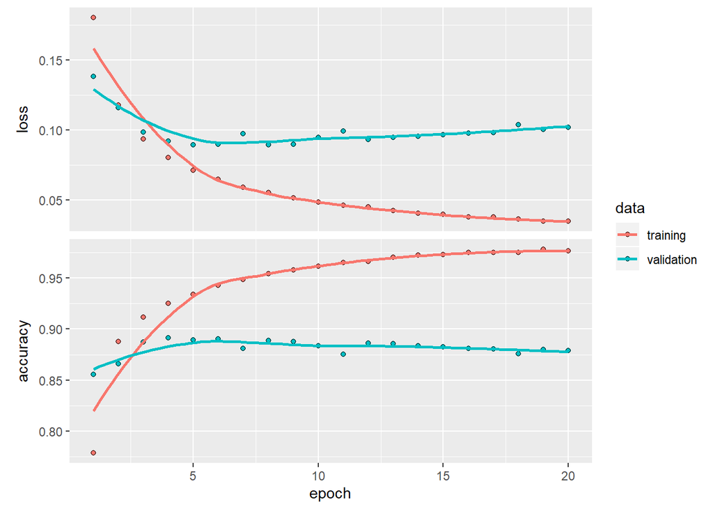

```r
plot(history)
```

```r
model %>% fit(x_train, y_train, epochs = 5, batch_size = 512)
results <- model %>% evaluate(x_test, y_test)

results
```

```
## $loss
## [1] 0.1052883
##
## $accuracy
## [1] 0.87408
```

```r
model %>% predict(x_test[1:10,])
```

```
##               [,1]
##  [1,] 0.0335378349
##  [2,] 0.9999926090
##  [3,] 0.9530960321
##  [4,] 0.9303712249
##  [5,] 0.9908401966
##  [6,] 0.7981160879
##  [7,] 0.9999314547
##  [8,] 0.0009990931
##  [9,] 0.9834594131
## [10,] 0.9996392727
```

This network begins to overfit after five epochs

# 3- Hidden layer network without regualrization and dropout

3-hidden layer network with 64, 32 and 16 units tanh activation mse loss function

```r
model <- keras_model_sequential() %>%
  layer_dense(units = 64, activation = "tanh", input_shape = c(10000)) %>%
  layer_dense(units = 32, activation = "tanh") %>%
  layer_dense(units = 16, activation = "tanh") %>%
  layer_dense(units = 1, activation = "sigmoid")

model %>% compile(
  optimizer = "rmsprop",
  loss = "mse",
  metrics = c("accuracy")
)

history <- model %>% fit(
  partial_x_train,
  partial_y_train,
  epochs = 20,
  batch_size = 512,
  validation_data = list(x_val, y_val)
)

str(history)
```

```
## List of 2
##  $ params :List of 7
##   ..$ batch_size   : int 512
##   ..$ epochs       : int 20
##   ..$ steps        : num 30
##   ..$ samples      : int 15000
##   ..$ verbose      : int 0
##   ..$ do_validation: logi TRUE
##   ..$ metrics      : chr [1:4] "loss" "accuracy" "val_loss" "val_accuracy"
##  $ metrics:List of 4
##   ..$ loss        : num [1:20] 0.1518 0.0717 0.0531 0.0392 0.0335 ...
##   ..$ accuracy    : num [1:20] 0.781 0.905 0.931 0.951 0.958 ...
##   ..$ val_loss    : num [1:20] 0.0956 0.0872 0.0868 0.1039 0.0952 ...
##   ..$ val_accuracy: num [1:20] 0.871 0.882 0.884 0.868 0.88 ...
##  - attr(*, "class")= chr "keras_training_history"
```

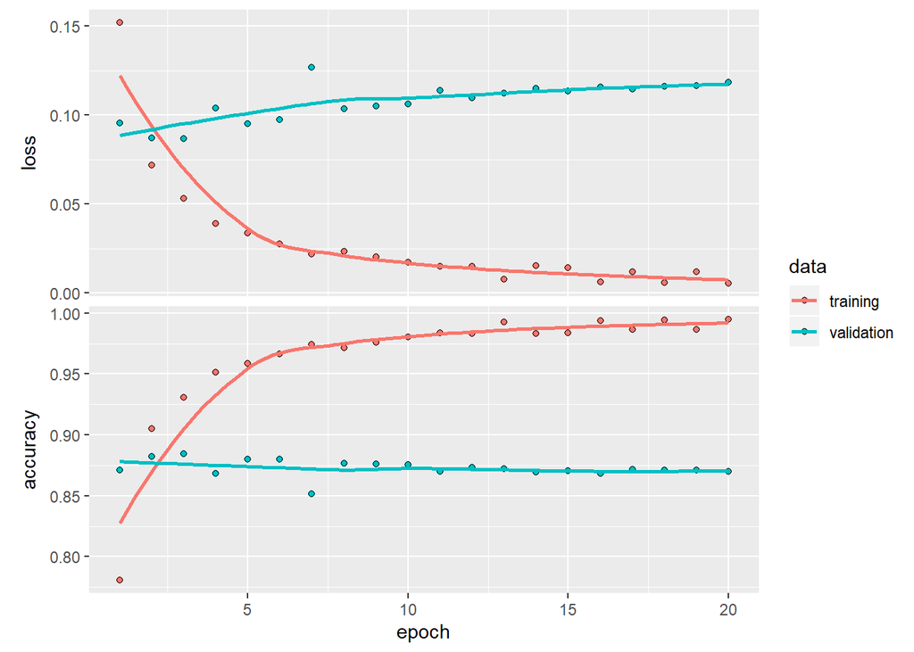

```r
plot(history)
```

```r
model %>% fit(x_train, y_train, epochs = 2, batch_size = 512)
results <- model %>% evaluate(x_test, y_test)

results
```

```
## $loss
## [1] 0.1128345
##
## $accuracy
## [1] 0.8626
```

```r
model %>% predict(x_test[1:10,])
```

```
##              [,1]
##  [1,] 0.027893186
##  [2,] 0.995972395
##  [3,] 0.982637763
##  [4,] 0.962142587
##  [5,] 0.995504856
##  [6,] 0.981666088
##  [7,] 0.995837927
##  [8,] 0.004628211
##  [9,] 0.993886411
## [10,] 0.995577574
```

[output not shown]

[figure not shown]

```r
str(history)
```

[output not shown]

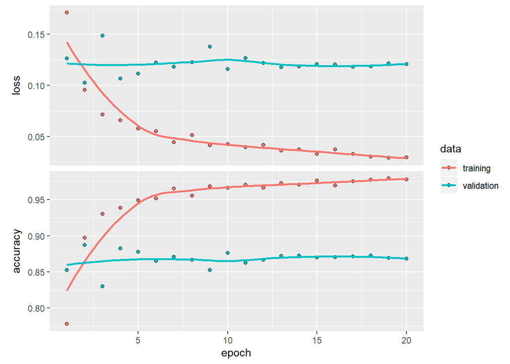

```r
plot(history)
```

```r
model %>% fit(x_train, y_train, epochs = 3, batch_size = 512)
results <- model %>% evaluate(x_test, y_test)

results
```

```
## $loss
## [1] 0.1161434
##
## $accuracy
## [1] 0.86492
```

```r
model %>% predict(x_test[1:10,])
```

```
##              [,1]
##  [1,] 0.048382699
##  [2,] 0.998516798
##  [3,] 0.985065222
##  [4,] 0.909110069
##  [5,] 0.995410740
##  [6,] 0.906623244
##  [7,] 0.998501956
##  [8,] 0.004408926
##  [9,] 0.987561464
## [10,] 0.996144891
```

# 3-layer network with regualrization

3-hidden layer network with 64, 32 and 16 units relu activation mse loss function regularization technique

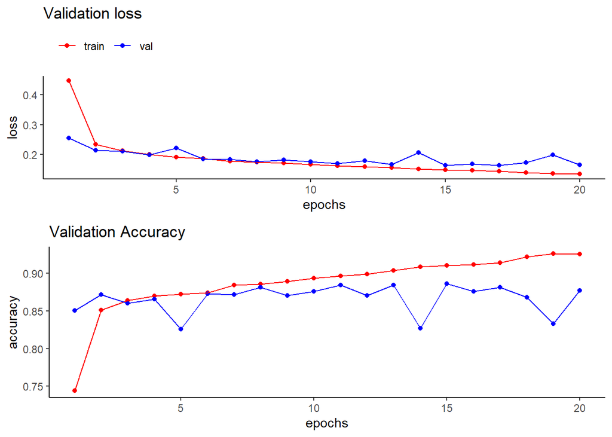

```r
model <- keras_model_sequential() %>%
  layer_dense(units = 64, kernel_regularizer = regularizer_l1(.0001), activation = "relu", input_shape = c(10000)) %>%
  layer_dense(units = 32, kernel_regularizer = regularizer_l1(.0001), activation = "relu") %>%
  layer_dense(units = 16, kernel_regularizer = regularizer_l1(.0001), activation = "relu") %>%
  layer_dense(units = 1, activation = "sigmoid")

model %>% compile(
  optimizer = "rmsprop",
  loss = "mse",
  metrics = c("accuracy")
)

history <- model %>% fit(
  partial_x_train,
  partial_y_train,
  epochs = 20,
  batch_size = 512,
  validation_data = list(x_val, y_val)
)
hist1 <- as.data.frame(history$metrics)
names(hist1) <- c("train-loss","train-accuracy","val_loss","val_accuracy")
hist1 <- hist1 %>% mutate(epochs = 1:n()) %>% gather("split","values",-epochs) %>% separate(split,c("split","metric")) %>% spread(metric,values)

g1<- ggplot(hist1,aes(x=epochs,y=loss,color=split)) + geom_point() + geom_line() + theme_classic() + ggtitle("Validation loss") + theme(legend.position = "top",legend.justification = "left",legend.title = element_blank()) +scale_color_manual(values = c("red","blue"))
g2<- ggplot(hist1,aes(x=epochs,y=accuracy,color=split)) + geom_point(show.legend = F) + geom_line(show.legend = F) + theme_classic() + ggtitle("Validation Accuracy") + theme(legend.position = "top",legend.justification = "left",legend.title = element_blank()) + scale_color_manual(values = c("red","blue"))
plot_grid(g1,g2,nrow=2)
```

```r
str(history)
```

```
## List of 2
##  $ params :List of 7
##   ..$ batch_size   : int 512
##   ..$ epochs       : int 20
##   ..$ steps        : num 30
##   ..$ samples      : int 15000
##   ..$ verbose      : int 0
##   ..$ do_validation: logi TRUE
##   ..$ metrics      : chr [1:4] "loss" "accuracy" "val_loss" "val_accuracy"
##  $ metrics:List of 4
##   ..$ loss        : num [1:20] 0.447 0.234 0.213 0.201 0.191 ...
##   ..$ accuracy    : num [1:20] 0.744 0.851 0.864 0.87 0.872 ...
##   ..$ val_loss    : num [1:20] 0.255 0.213 0.211 0.199 0.221 ...
##   ..$ val_accuracy: num [1:20] 0.851 0.872 0.86 0.865 0.826 ...
##  - attr(*, "class")= chr "keras_training_history"
```

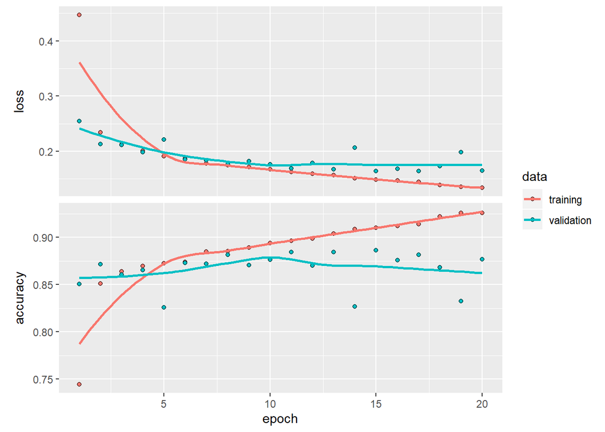

```r
plot(history)
```

```r
model %>% fit(x_train, y_train, epochs = 9, batch_size = 512)
results <- model %>% evaluate(x_test, y_test)

results
```

```
## $loss
## [1] 0.1553604
##
## $accuracy
## [1] 0.8772
```

```r
model %>% predict(x_test[1:10,])
```

```
##             [,1]
##  [1,] 0.06469330
##  [2,] 0.97986472
##  [3,] 0.95221692
##  [4,] 0.94271946
##  [5,] 0.94220114
##  [6,] 0.91450799
##  [7,] 0.96542931
##  [8,] 0.01445848
##  [9,] 0.93508726
## [10,] 0.96256042
```

# 3-Hidden layer network with regualrization and dropout

```r
model <- keras_model_sequential() %>%
  layer_dense(units = 32, kernel_regularizer = regularizer_l1(.001), activation = "tanh", input_shape = c(10000)) %>%
  layer_dropout(rate = 0.5) %>%
  layer_dense(units = 16, kernel_regularizer = regularizer_l1(.001), activation = "tanh") %>%
  layer_dropout(rate = 0.5) %>%
  layer_dense(units = 16, kernel_regularizer = regularizer_l1(.001), activation = "tanh") %>%
  layer_dropout(rate = 0.5) %>%
  layer_dense(units = 1, activation = "sigmoid")


model %>% compile(
  optimizer = "rmsprop",
  loss = "mse",
  metrics = c("accuracy")
)

history <- model %>% fit(
  partial_x_train,
  partial_y_train,
  epochs = 20,
  batch_size = 512,
  validation_data = list(x_val, y_val)
)

str(history)
```

```
## List of 2
##  $ params :List of 7
##   ..$ batch_size   : int 512
##   ..$ epochs       : int 20
##   ..$ steps        : num 30
##   ..$ samples      : int 15000
##   ..$ verbose      : int 0
##   ..$ do_validation: logi TRUE
##   ..$ metrics      : chr [1:4] "loss" "accuracy" "val_loss" "val_accuracy"
##  $ metrics:List of 4
##   ..$ loss        : num [1:20] 1.284 0.554 0.515 0.488 0.466 ...
##   ..$ accuracy    : num [1:20] 0.641 0.744 0.774 0.796 0.811 ...
##   ..$ val_loss    : num [1:20] 0.573 0.514 0.497 0.457 0.441 ...
##   ..$ val_accuracy: num [1:20] 0.812 0.83 0.805 0.853 0.853 ...
##  - attr(*, "class")= chr "keras_training_history"
```

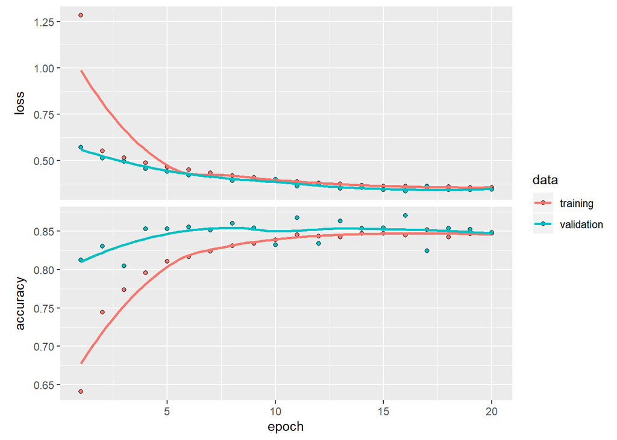

```r
plot(history)
```

```r
model %>% fit(x_train, y_train, epochs = 8, batch_size = 512)
results <- model %>% evaluate(x_test, y_test)

results
```

```
## $loss
## [1] 0.3290033
##
## $accuracy
## [1] 0.86988
```

```r
model %>% predict(x_test[1:10,])
```

```
##             [,1]
##  [1,] 0.16677526
##  [2,] 0.99705756
##  [3,] 0.71637803
##  [4,] 0.74839443
##  [5,] 0.87404490
##  [6,] 0.63304579
##  [7,] 0.95222259
##  [8,] 0.02836111
##  [9,] 0.93480694
## [10,] 0.89050114
```

```r
model <- keras_model_sequential() %>%
  layer_dense(units = 64, kernel_regularizer = regularizer_l1(.0001), activation = "tanh", input_shape = c(10000)) %>%
  layer_dropout(rate = 0.5) %>%
  layer_dense(units = 32, kernel_regularizer = regularizer_l1(.0001), activation = "tanh") %>%
  layer_dropout(rate = 0.5) %>%
  layer_dense(units = 16, kernel_regularizer = regularizer_l1(.0001), activation = "tanh") %>%
  layer_dropout(rate = 0.5) %>%
  layer_dense(units = 1, activation = "sigmoid")

model %>% compile(
  optimizer = "rmsprop",
  loss = "mse",
  metrics = c("accuracy")
)
```

# Using a trained network to generate predictions on new data

After having trained a network, you will want to use it in a practical setting. You can generate the likelihood of reviews being positive by using the predict method:

```r
model %>% fit(x_train, y_train, epochs = 8, batch_size = 512)
results <- model %>% evaluate(x_test, y_test)

results
```

```
## $loss
## [1] 0.2119408
##
## $accuracy
## [1] 0.86024
```

```r
model %>% predict(x_test[1:10,])
```

```
##             [,1]
##  [1,] 0.10418516
##  [2,] 0.99644095
##  [3,] 0.98565209
##  [4,] 0.96833950
##  [5,] 0.98441136
##  [6,] 0.94565535
##  [7,] 0.99553788
##  [8,] 0.01240376
##  [9,] 0.99211770
## [10,] 0.98667866
```

As you can see, the network is very confident for some samples (0.99 or more, or 0.02 or less) but less confident for others.